# E Commerce End to End Data Analytics Project :

#### Technologies Used

• Excel – Initial data exploration and validation

• MySQL – Data cleaning, joins, business queries, and feature engineering

• Python (Pandas, NumPy, Matplotlib, Seaborn, SciPy) – EDA and statistical analysis

• Tableau Public – Interactive dashboard development

• Jupyter Notebook – Documentation and storytelling

#### This Project has 5 Phases :

1. Business Understanding - Commencement of the project
2. Excel - Basic Data Understanding
3. SQL - Data preparation and solving business questions
4. Python - Exploratory Data Analysis and Statistical Testing
5. Tableau - Dashboard Development

## I. Business Understanding

### Project Overview

An e-commerce company generates large amounts of transactional data through customer purchases, product sales, seller activities, and order deliveries. Analyzing this data can help identify sales trends, customer behavior patterns, operational inefficiencies, and opportunities for business growth.

#### Dataset Source

- Source: Kaggle
- Rows: 89,000+
- Tables: Customers, Orders, Payments, Products, Order Items
- Country: Brazil

### Problem Statement

The company has accumulated a large volume of customer, order, product, seller, payment, and review data. However, raw data alone does not provide meaningful insights for decision-making.

The challenge is to transform this data into valuable information that can help the company:

- Improve sales performance and revenue generation
- Understand customer purchasing behavior
- Identify high value customer segments
- Evaluate product category performance
- Analyze payment trends and customer preferences
- Improve delivery efficiency and logistics operations

### Business Objectives

The primary objective of this project are:

1. Sales performance Analysis
- Revenue Trends
- Order Trends
- Top Categories
- Average Order Value
2. Customer Analysis & Segmentation
- Customer distribution by state/city
- High/Medium/Low Value Customers
- Order Frequency analysis
3. Product Analysis
- Best Selling Categories
- Product Pricing insights
- Highest revenue categories
4. Delivery and Logistics Analysis
- Average Delivery Time
- On-Time vs Delayed deliveries
- Delivery performance by region

### KPIs

1. Sales KPIs
- Total Revenue
- Total Orders
- Average Order Value
- Monthly Revenue Growth
- Annual Revenue Trend
2. Customer KPIs
- Total Customers
- Customers by state
- Customers by city
- Orders per customer
3. Customer Segmentation KPIs
- Revenue by Customer segment
- Average spending by segment
- Segment distribution
4. Product KPIs
- Revenue by Product Category
- Orders by Product Category
- Average Product Price
- Catgeory Contribution Percentage
5. Payment KPIs
- Revenue by payment Method
- Payment Method Usage Percentage
- Average Installments per order
6. Delivery KPIs
- Average Delivery Time
- On-Time Delivery percentage
- Delayed delivery Percentage
- Average Delay Duration

## II. Excel - Basic Data Undestanding

#### The goal of this dataset is to understand the data before importing it into sql.

TABLE I - Products

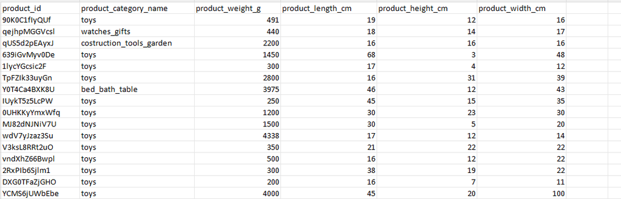

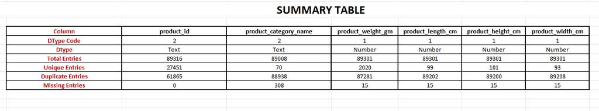

- There are total 27451 unique products which belong to 70 different product categories. And there are 308 entries for which there is no product category name.

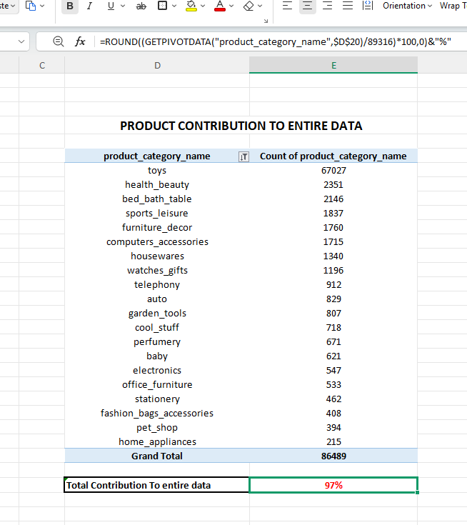

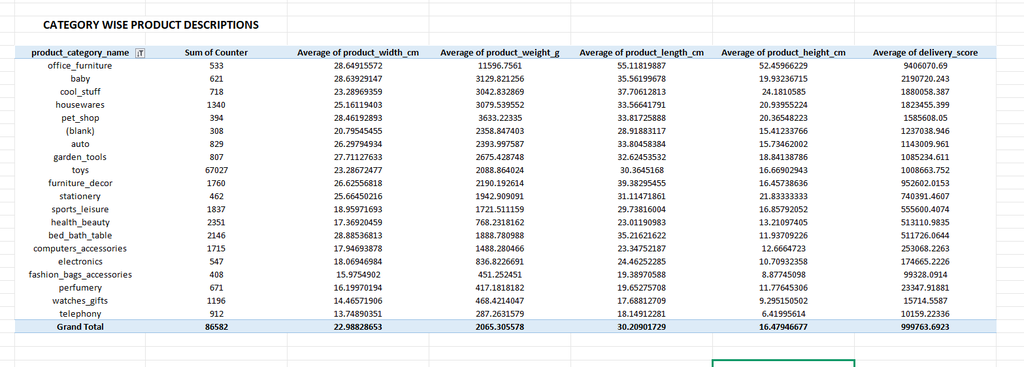

Table Description :

1. This Table has the description of various products.
2. In Csv this has about 89k entries. But only 27451 are unique products.
3. This table is connected to other tables on product_id column.
4. Majority of the products are toys which are 67000+.

#### TABLE II - Orders

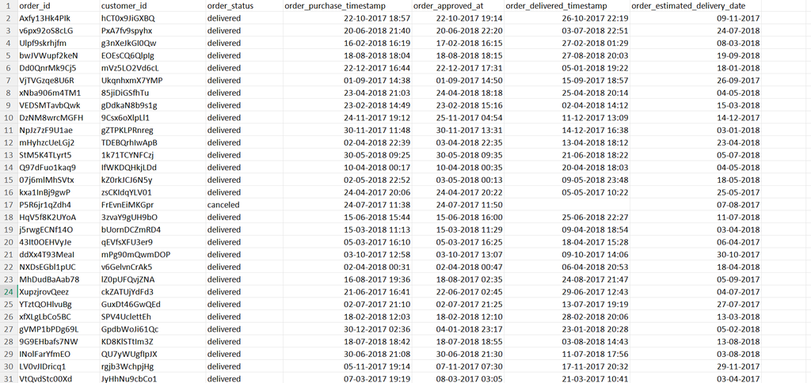

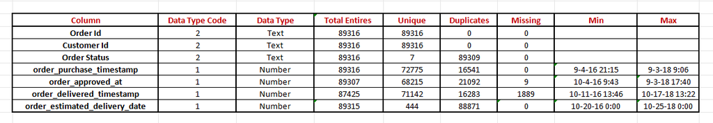

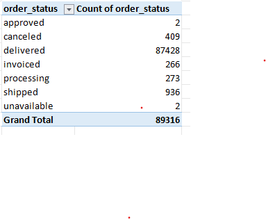

- From the total of 89316 orders over 97% were fullfilled. About 400 were cancelled.
- And some of the orders were in the journey.
- At this point I created a year column, a month column and a day column for understanding year on year, month on month trend.

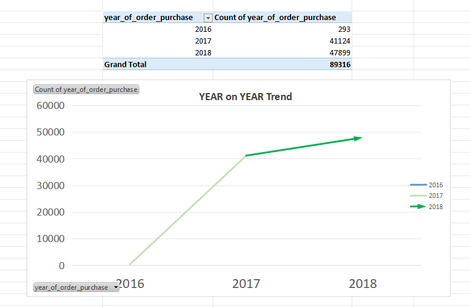

- The graph show a strong upward trend from 2016 being the lowest at almost nothing to all the way above 40,000 in the first year. Most probably the business started in 2016.
- In 2018, the business got even more orders in 2018 compared to 2017 which can be said as a successful growth.
- In General the business appears to be successful.

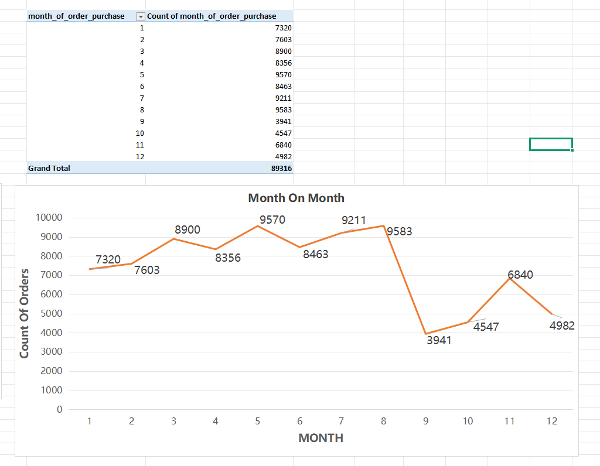

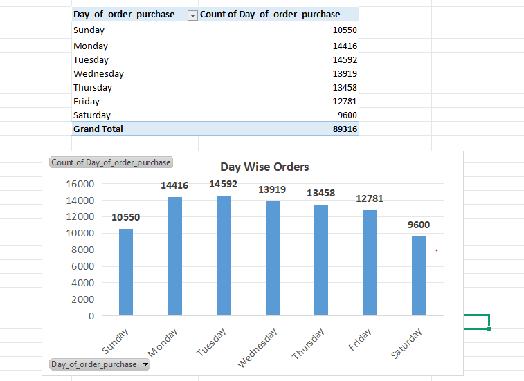

- The graph depicts the fact that most amount of orders were made on Mondays and Tuesdays. The rest of the week appears to be good as well but Saturdays and sundays were considerably less performing.
- I Also created a column to determine the delay in days.

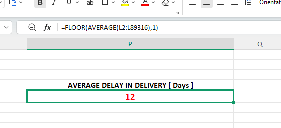

#### TABLE III - Customers

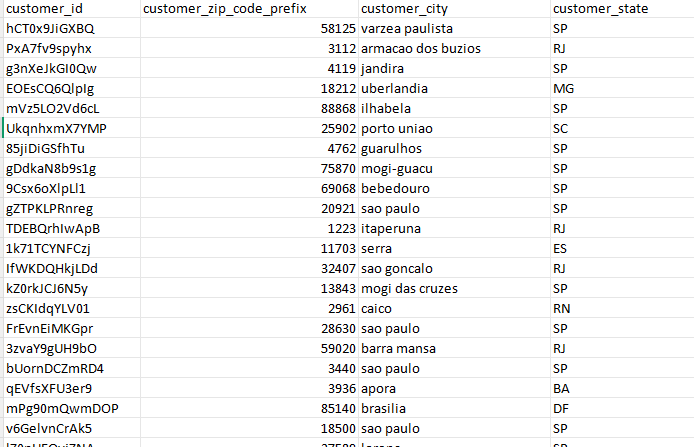

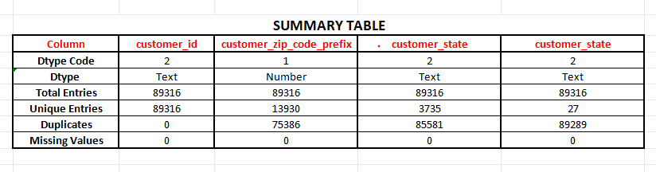

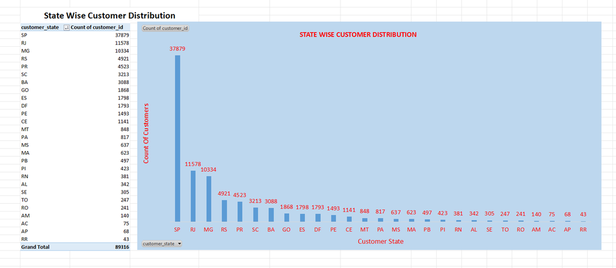

- From the graph we can understand that the state SP is the biggest market for the business with almost 38000 customers which is more than twice of the size of market in the next states which are RJ and MG.
- These 3 states contribute 67% of the total customers of the business in the course of 2 years.
- The following states which are RS, PR, SC and BA are potential markets that can be converted in good performing markets.

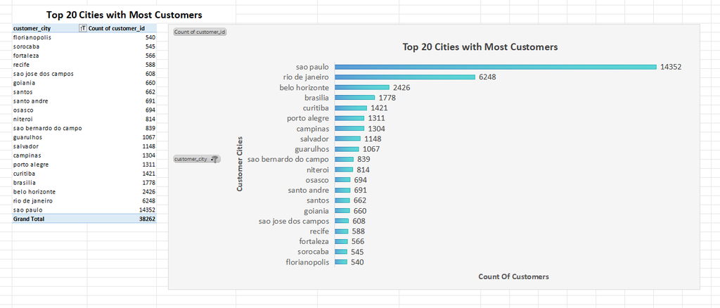

#### TABLE IV - Payments

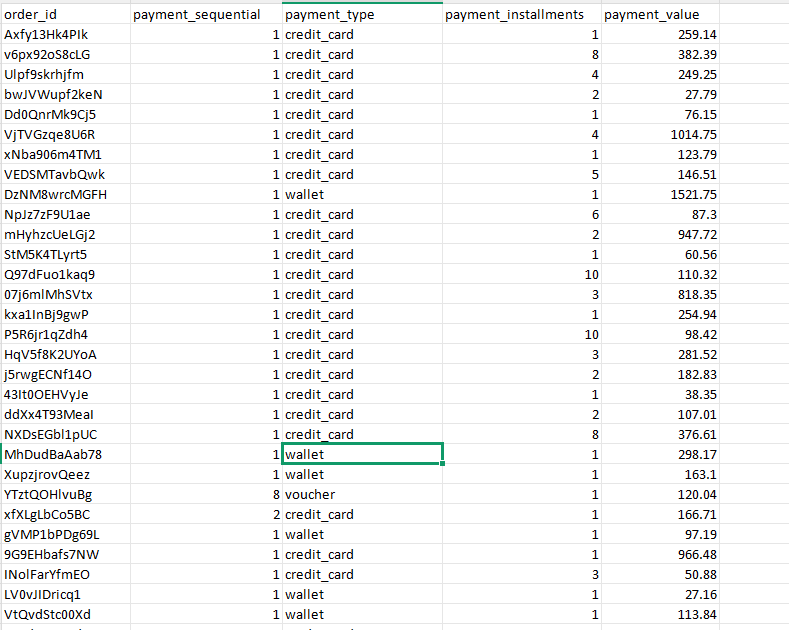

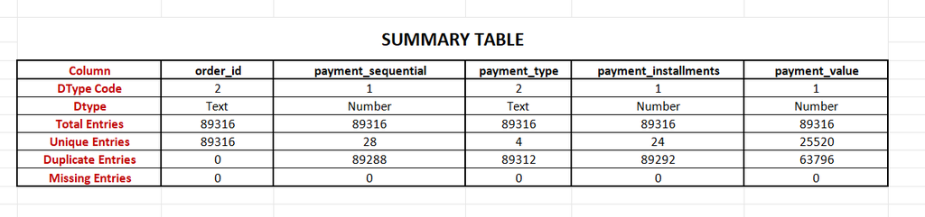

- The business accepts payments from 4 different types of modes which are credit card, wallet, vouchers and debit_cards.

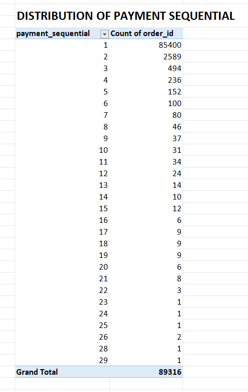

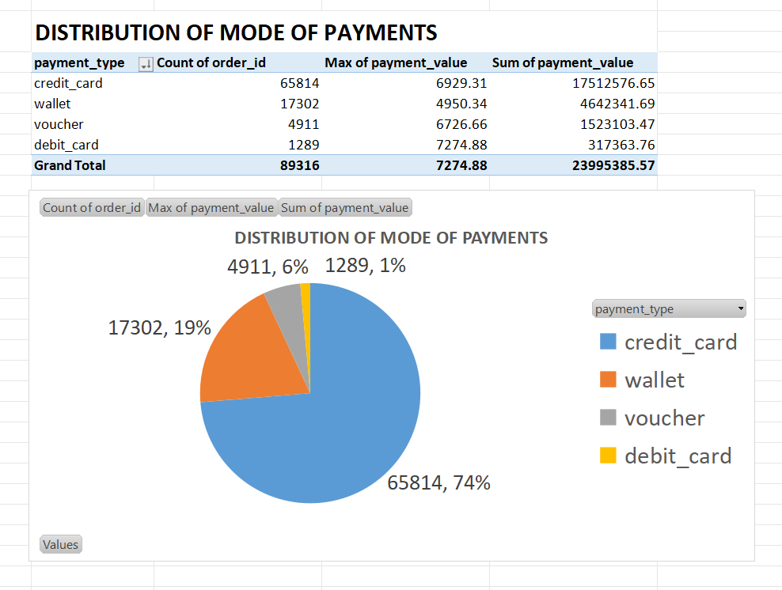

- 74% of the orders were placed using credit-card which gives us the mode of payment people use most often. The reason can be distributing the large payments in small installments so that it cant effect much and also most of the times using credit-cards brind good cashbacks and offers.
- Wallet option bring about 19% of orders and the least amount of orders are from debit_card.

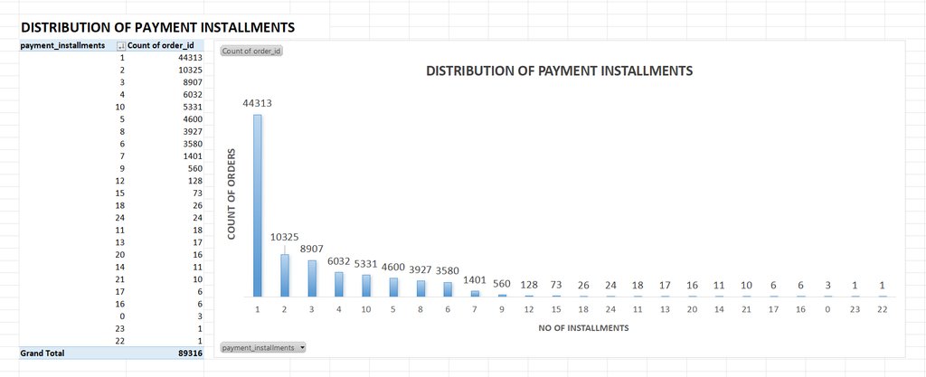

#### TABLE V - Order Items

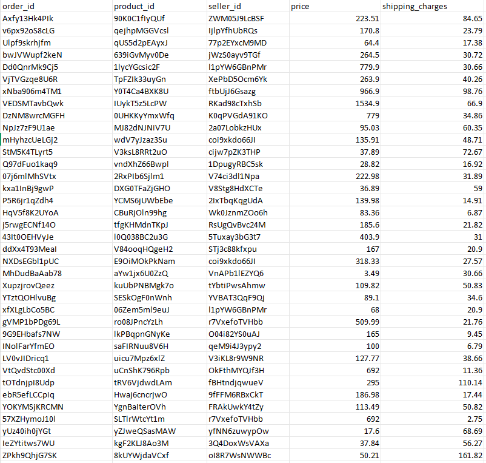

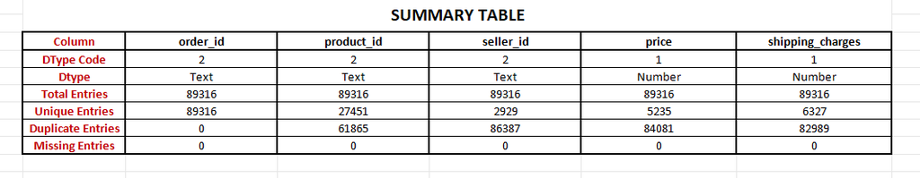

- There are total of 2929 sellers supplying about 27500 unique products to the business.

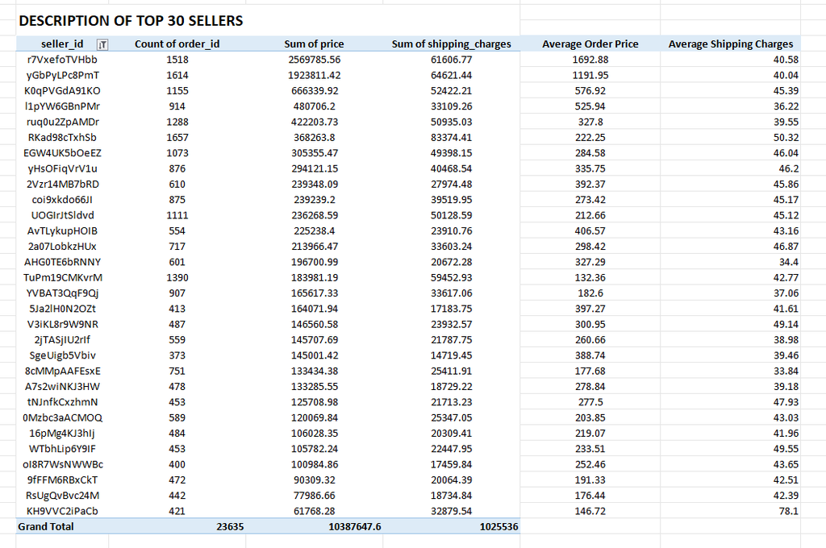

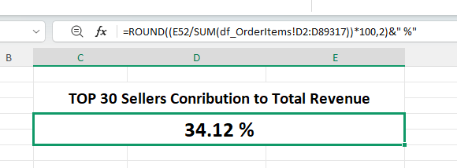

- From the total of 2929 different sellers, the top 30 sellers contribute about 34% of the total business revenue.

## III. SQL - Data Preparation and solving business Questions

#### The Schema of the dataset is given in the picture :

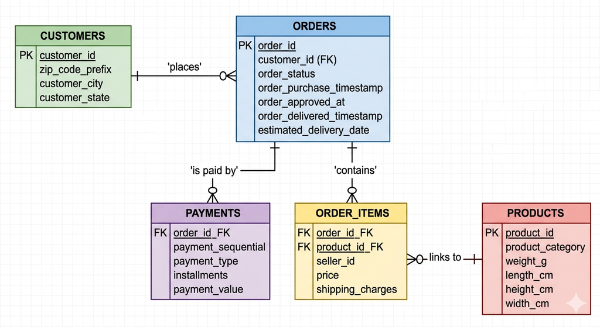

#### A. Database Creation and Data Loading [ MySQL Workbench ]

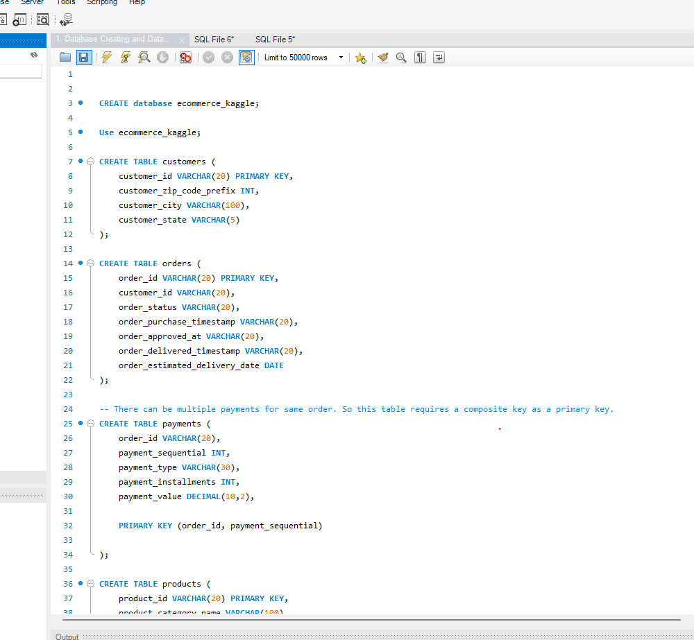

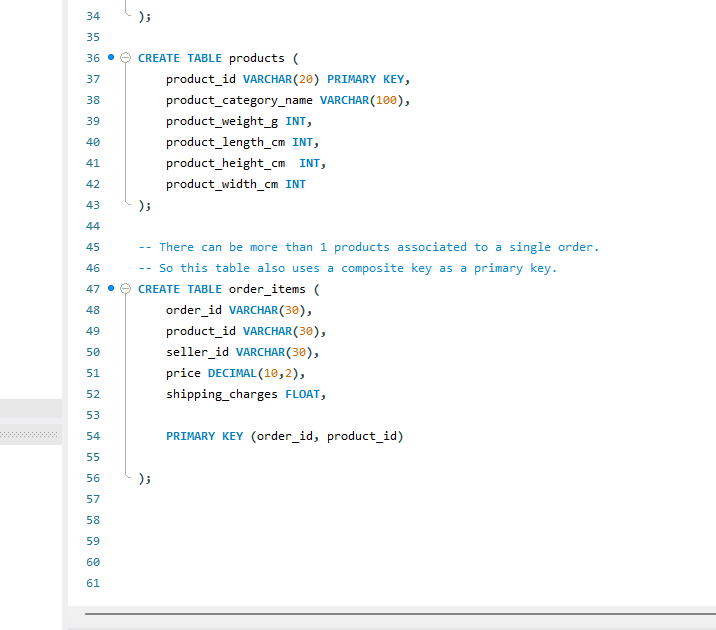

- I created the database and the tables inside the database manually. And Loaded the data into the tables using the **TABLE DATA IMPORT WIZARD** of MySQL.

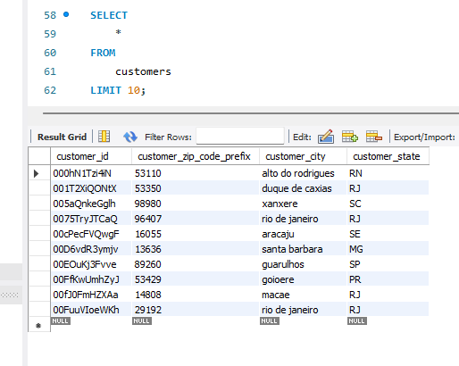

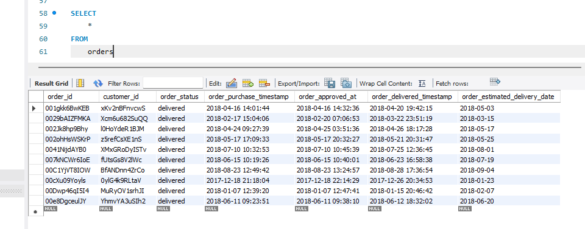

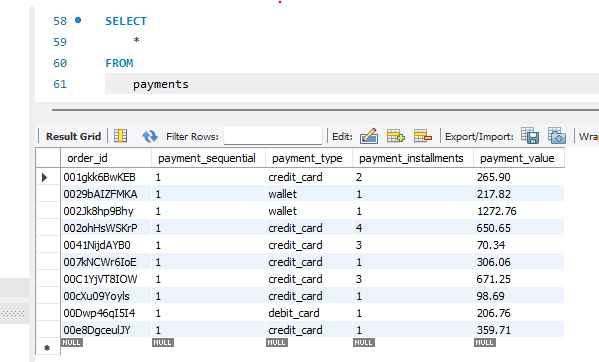

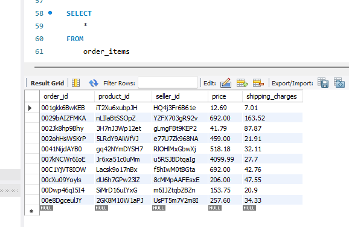

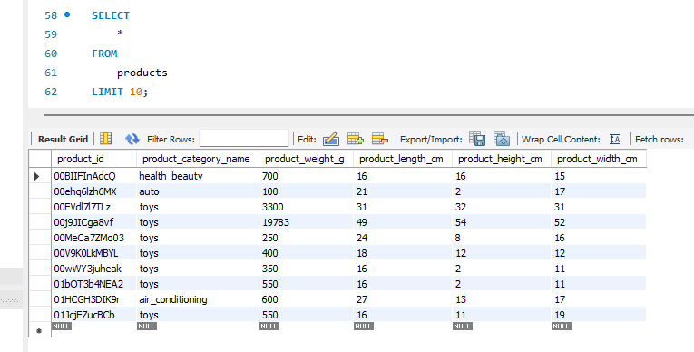

- The database is created, the data is loading and queries are operating normally.